# **Causal Forest**

**Author:** [Anthony Strittmatter](http://www.anthonystrittmatter.com)

The charity Freedom from Hunger implemented a randomised trial to improve its direct marketing campaign. The solicitations letters vary by whether they include a discussion of their program's impact as measured by scientific research. We investigate how donors respond to information about a charity’s effectiveness. The base script, used for both treatment and control, included a standard qualitative story about an individual beneficiary. The allocation of the ''scientific mailer'' is randomised.

Reference: [Karlan and Wood (2017)](https://www.sciencedirect.com/science/article/pii/S2214804316300490)

Variable list:

- **char_giving**: Donation in response to mail
- **treat**: Mailer includes a discussion about the program impact as measured by scientific research
- **amount_pre**: Total amount given before mailer
- **amount_lastpre**: Amount of last gift before mailer
- **amount_maxpre**: Largest gift before mailer
- **H_number_yearbefore**: # of donations given in year prior to experiment
- **H_ngifts**: Number of donations over donor's giving history before mailer
- **H_littleask**: Received mailer with small ask string-small donor in past
- **H_bigask**: Received mailer with big ask string-big donor in past
- **H_nyears**: Number of years donor is in database before specified mailer
- **H_frequency**: Number of gifts per year (that donor was in donor database before specified mail)
- **H_medinc**: Median zip code income
- **H_medinc_mdum**: Dummy to reflect replacement to 0 when missing
- **H_Avg_years_ed**: Average years of education in census tract
- **H_Avg_years_ed_mdum**: Dummy to reflect replacement to 0 when missing

## Load Packages

```r
########################  Load Packages  ########################

# List of required packages
pkgs <- c('fBasics', 'corrplot', 'tidyverse', 'grf', 'plotmo')

# Load packages
for(pkg in pkgs){
    library(pkg, character.only = TRUE)
}
options(warn=-1)     # supress warnings

print('All packages successfully installed and loaded.')

##################################################################
```

```
[1] "All packages successfully installed and loaded."
```

## Load Data

```r
########################  Load Data Frame  ########################

# Load data frame
df <- read.csv("fundraising.csv",header=TRUE, sep=",")

# Outcome Variable
outcome <- c("char_giving")

# Treatment Variables
treatment <- c("treat")

# Covariates/Features
covariates <- c("amount_pre", "amount_lastpre", "amount_maxpre", "H_number_yearbefore", "H_ngifts",
                "H_littleask", "H_bigask", "H_nyears", "H_frequency", "H_medinc", "H_medinc_mdum",
                "H_Avg_years_ed", "H_Avg_years_ed_mdum")


all_variables <- c(outcome, treatment, covariates)

print('Data frame successfully loaded and sample selected.')

####################################################################
```

```
[1] "Data frame successfully loaded and sample selected."
```

## Desriptive Statistics

#### Mean and Standard Deviations

```r
########################  Table with Descriptive Statistics  ########################

desc <- fBasics::basicStats(df) %>% t() %>% as.data.frame() %>%
  select(Mean, Stdev, Minimum, Maximum, nobs)
print(round(desc, digits=2))

#####################################################################################
```

```
                        Mean    Stdev Minimum   Maximum  nobs
char_giving            14.94   267.05    0.00  30000.00 23122
treat                   0.50     0.50    0.00      1.00 23122
amount_pre            320.90  1137.65    1.00  62849.99 23122
amount_lastpre         50.79   266.59    1.00  25707.36 23122
amount_maxpre          71.27   353.36    1.00  25707.36 23122
H_number_yearbefore     0.74     1.16    0.00     21.00 23122
H_ngifts                6.97    11.58    1.00    261.00 23122
H_littleask             0.88     0.33    0.00      1.00 23122
H_bigask                0.12     0.33    0.00      1.00 23122
H_nyears                7.35     7.08    1.00     54.00 23122
H_frequency             0.86     0.83    0.08     10.50 23122
H_medinc            52056.29 24061.48    0.00 200001.00 23122
H_medinc_mdum           0.03     0.18    0.00      1.00 23122
H_Avg_years_ed         14.00     2.98    0.00     21.05 23122
H_Avg_years_ed_mdum     0.03     0.18    0.00      1.00 23122
```

The outcome variable *char_giving* is has extreme values.

### Corrleations

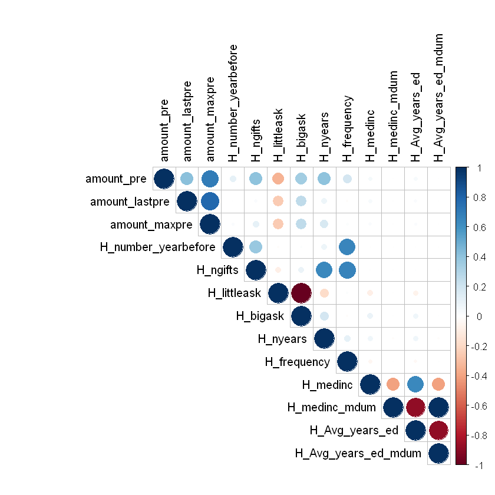

```r
########################  Correlation Matrix  ########################

corr = cor(df[,-c(1:2)])
corrplot(corr, type = "upper", tl.col = "black")

######################################################################
```

Several variables are highly correlated. For example, total, last, and maximum previous donation amount are positively correlated.

### Prepare Data for Analysis

We randomly partition the data into a training (80\%) and hold-out sample (20\%). Furthermore, we define the outcome, treatment and control variables for the later analysis.

```r
########################  Partition the Samples  ########################

# Partition Hold-Out-Sample
df_part <- modelr::resample_partition(df, c(obs = 0.8, hold_out = 0.2))
df_obs <- as.data.frame(df_part$obs) # Training and estimation sample
df_hold_out <- as.data.frame(df_part$hold_out) # Hold-out-sample

print('Samples are partitioned.')

########################  Generate Variables  ########################

# Outcome
giving_hold_out <- as.matrix(df_hold_out[,1])
giving_obs <- as.matrix(df_obs[,1])

# Treatment
treat_hold_out <- as.matrix(df_hold_out[,2])
treat_obs <- as.matrix(df_obs[,2])

# Covariates
covariates_hold_out <- as.matrix(df_hold_out[,c(3:ncol(df_hold_out))])
covariates_obs <- as.matrix(df_obs[,c(3:ncol(df_obs))])

print('The data is now ready for your analysis!')

#######################################################################
```

```
[1] "Samples are partitioned."
[1] "The data is now ready for your analysis!"
```

# Causal Forest

```r
########################  Causal Forest  ########################
set.seed(100244)

# Tuning parameters
min_tree = 100 # Minimum size of terminal leaves
num_trees = 1000 # Number of trees in forest
cov_frac = 1/2 # Fraction of covariates in each tree
sample_part= 0.5 # Fraction of sample used for each tree (subsampling)

# Caual Forest
cates <- causal_forest(covariates_obs, giving_obs, treat_obs,
                  sample.fraction = sample_part, mtry = floor(cov_frac*ncol(covariates_obs)),
                  num.trees = num_trees, min.node.size = min_tree,
                  honesty = TRUE, honesty.fraction = 0.5)

print('Forest is ready!')

###################################################################
```

```
[1] "Forest is ready!"
```

We plot an example tree from the causal forest.

```r
#################################################################################

# Plot one tree from the random forest
plot(tree <- get_tree(cates, 1))
# the last number is the tree number
# it can be varied from 1 to 1000

#################################################################################
```

[interactive chart not shown]

We count the number of times each variable is used for tree splitting on each tree depth (up-to depth 4).

```r
#################################################################################

# Count the splitting frequencies for each covariate
split <- split_frequencies(cates, max.depth = 4)
# max.depth specifies the maximum tree depth we consider

# Label the results
colnames(split) <- colnames(covariates_obs)
rownames(split) <- c("Depth 1", "Depth 2", "Depth 3", "Depth 4")

print(t(split))

#################################################################################
```

```
                    Depth 1 Depth 2 Depth 3 Depth 4
amount_pre              158     233     237     311
amount_lastpre          123      84     129     138
amount_maxpre           104     165     156     158
H_number_yearbefore      16      33      33      55
H_ngifts                 60     114     151     169
H_littleask              22      28      37      17
H_bigask                 17      34      40      18
H_nyears                152     177     185     197
H_frequency              36      94     140     154
H_medinc                199     132     177     248
H_medinc_mdum             0       0       0       0
H_Avg_years_ed          108     148     229     261
H_Avg_years_ed_mdum       0       0       0       0
```

The median ZIP code income, years in donor data base, total previous donation amount, maximum previous donation amount, average census district education appear to be important heterogeneity variables.

**Question:** Can we compare the split frequency of continuous and dummy variables?

We can also use the causal forest to estimate the average treatment effects:

```r
######################### ATE ###############################

average_treatment_effect(cates, target.sample = c("all"))

#############################################################
```

**estimate**

2.99636418063053

**std.err**

4.50140104508948

We can count how often the estimated CATEs are positive/negative:

```r
###############################################################################

# Calculate the predicted effect size for each observation
fit <- predict(cates, covariates_hold_out, estimate.variance = FALSE)$predictions

# Count the observations with positive and negative effects
print(paste0("Number of individuals with positive effects: ", length(fit[fit>=0])))
print(paste0("Number of individuals with negative effects: ", length(fit[fit<0])))

print(paste0("Share of individuals with positive effects: ", round(100*length(fit[fit>=0])/length(fit),digits=1), "%"))

###############################################################################
```

```
[1] "Number of individuals with positive effects: 4126"
[1] "Number of individuals with negative effects: 499"
[1] "Share of individuals with positive effects: 89.2%"
```

Alternatively, we can also plot the cumulative distribution of the predicted CATEs (out-of-sample).

[figure not shown]

```r
###############################################################################
################ Plot Cumulative Distribution of CATEs ########################
###############################################################################

plot(ecdf(fit), col="blue", xlim = c(-25,25), xlab="Effect Size (in Dollars)",
     ylab="Cumulative Distribution", main="Cumulative Distibution of the CATEs")
abline(v=0, col="red")

###############################################################################
```

Finallw, we report the descriptive statistics of the covariates for the individuals with positive and negative effects, respectively.

```r
###############################################################################
######################## Description of CATEs #################################
###############################################################################

## Means and standard deviations for individuals with positive effects
desc_1 <- fBasics::basicStats(covariates_hold_out[fit >= 0,]) %>% t() %>% as.data.frame() %>% select(Mean, Stdev)

## Means and standard deviations for individuals with negative effects
desc_0 <- fBasics::basicStats(covariates_hold_out[fit < 0,]) %>% t() %>% as.data.frame() %>% select(Mean, Stdev)

# Make table and add standardized differences
desc <- cbind(desc_1,desc_0,
        100*abs(desc_1[,1]-desc_0[,1])/sqrt(0.5*(desc_1[,2]^2+desc_0[,2]^2)))
colnames(desc) <- c("Mean (Pos.)", "Std.Dev. (Pos.)", "Mean (Neg.)", "Std.Dev. (Neg.)", "Std.Diff.")
print(round(desc, digits=2))

###############################################################################
```

```
                    Mean (Pos.) Std.Dev. (Pos.) Mean (Neg.) Std.Dev. (Neg.)
amount_pre               172.93          340.65     1250.59         2408.66
amount_lastpre            29.79           25.69      242.83         1343.08
amount_maxpre             35.47           35.94      359.47         1529.15
H_number_yearbefore        0.70            1.09        0.87            1.04
H_ngifts                   6.57           11.05        8.56           12.82
H_littleask                0.94            0.24        0.46            0.50
H_bigask                   0.06            0.24        0.54            0.50
H_nyears                   7.13            6.64        8.82            8.99
H_frequency                0.84            0.79        0.91            0.77
H_medinc               49234.58        22021.27    71294.26        34278.68
H_medinc_mdum              0.04            0.19        0.02            0.15
H_Avg_years_ed            13.80            3.01       15.22            2.74
H_Avg_years_ed_mdum        0.04            0.19        0.02            0.15
                    Std.Diff.
amount_pre              62.65
amount_lastpre          22.43
amount_maxpre           29.96
H_number_yearbefore     16.53
H_ngifts                16.62
H_littleask            122.29
H_bigask               122.29
H_nyears                21.45
H_frequency              8.91
H_medinc                76.57
H_medinc_mdum            7.32
H_Avg_years_ed          49.11
H_Avg_years_ed_mdum      7.32
```

We find now also for dummy variables (*H_littleask*,*H_bigask*) large standardized differences.

The standardized differences ($SD$) are defined as

$SD = 100 \displaystyle \cdot \frac{|\bar{X}_1 - \bar{X}_0|}{\sqrt{1/2 \cdot (\sigma_{X1}^2+\sigma_{X0}^2)}}$

where $\bar{X}_1$ and $\bar{X}_0$ are the means and $\sigma_{X1}$ and $\sigma_{X0}$ the standard deviations in the groups of individuals with postive and negative CATEs, respectively. Large standardized differences indicate a large inbalance between the characteristics of individuals with postive and negative CATEs.